# DO3 - Communication

2025-01-13

## Avant de commencer les statistiques

`R`-Studio est une interface pratique et complète.

\(\hookrightarrow\) permet de rédiger des rapports automatisés avec les fichiers `Rmd`.

\(\hookrightarrow\) fait de très beaux graphiques.

## R Markdown

## Un nom étonnant

`R`-markdown est un mix entre :

- le langage `R`
- le format `Markdown`

## `Markdown`

Il s’agit d’un langage à balises permettant de produire différents types de fichier.

\(~\) **Format** : PDF, HTML, documents, diapos, …

## Balises classiques

- pour écrire *en italique*, il faut écrire `*comme ça*`.
- pour écrire **en gras**, il faut écrire `**comme ça**`.
- pour écrire `des portions de code`, il faut écrire `` `comme ça` ``.
- si vous savez faire du \(\LaTeX\), il faut écrire `$comme ça$`.

## Exemple concret

**Entrée** :

```
Je peux écrire en *italique*, en **gras**, et même du `code`.

Grâce au $\LaTeX$ je connais l'identité d'Euler : $e^{i\pi} + 1 = 0$.
```

**Sortie** :

## Structure

Pour mieux structurer vos rapports, les titres, sous-titres se font à l’aide de `#` :

- un seul (`# Titre`) pour les titres.
- deux (`## Sous-titre`) pour les sous-titres.
- trois (`### Sous-sous-titre`) pour les sous-sous-titres.
- etc….

## `R Markdown`

Permet d’ajouter du code reproductible aux rapports `Markdown` via ce que l’on appelle des cellules (*chunks* en anglais).

## Exemple de code

**Entrée** :

````
La fonction `rnorm()` simule des gaussiennes.
```{r}
set.seed(12890926) # graine (Quia Sapientia)
rnorm(5)           # 5 gaussiennes centrées réduites
```
````

**Sortie** :

La fonction `rnorm()` simule des gaussiennes.

```r
set.seed(12890926) # graine (Quia Sapientia)
rnorm(5)           # 5 gaussiennes centrées réduites
```

```
## [1] -1.5555517  0.1756018 -0.5641544  0.2076129  0.6847056
```

## `R Markdown`

il est aussi possible d’afficher directement des graphiques (utile pour la suite ;) )

## Exemple d’affichage

Le volcan Maunga Whau (Mt Eden), Auckland, Nouvelle-Zélande

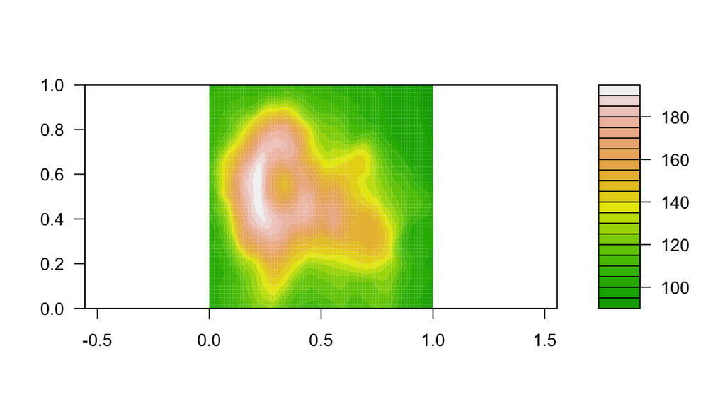

## Paramètres des cellules

- `echo = TRUE/FALSE` : affiche le code dans la sortie.
- `eval = TRUE/FALSE` : fait compiler le code.
- `fig.align = 'default'/'left'/'right'/'center'` : localisation de la figure.
- `fig.height` ou `fig.width` : taille des sorties de figure.
- `cache=TRUE/FALSE` : permet de ne pas recompiler les codes lorsque que l’on compile plusieurs fois le fichier `.Rmd`.

## `R Markdown`

- [Introduction complète](https://rmarkdown.rstudio.com/lesson-1.html)
- [Fiche résumée](https://raw.githubusercontent.com/rstudio/cheatsheets/master/rmarkdown-2.0.pdf)
- [RStudio](https://rstudio.com/)
- Ces diapos sur [GitHub](https://github.com/alxkpl/ig4-dataviz)

## La librairie ggplot2

## `ggplot2`

- Créé par Hadley Wickham en 2005.
- Page [wikipedia](https://en.wikipedia.org/wiki/Ggplot2).
- [Réference complète](https://ggplot2.tidyverse.org/index.html)
- [Fiche résumée](https://github.com/rstudio/cheatsheets/blob/master/data-visualization-2.1.pdf)
- C’est une librairie `R` stardard.

## Grammar of Graphics

- Un système cohérent pour faire des graphiques [ref](http://vita.had.co.nz/papers/layered-grammar.pdf).
- “Layered aesthetic mappings” : “couches” de choix esthétiques.
- On choisit un mode de représentation pour chaque composante du jeu de données.

## Syntaxe classique

```
> ggplot(données)
>  + aes(structure_du_graphe)
>  + type_de_graphe()
>  + autres_paramètres()
```

## Exemples

## Données climatiques

- Températures moyennes journalières [ECAD](https://www.ecad.eu/dailydata/index.php) (1950 - 2019)

```
##     city day_of_year month temperature
## 1 Embrun           1     1   1.7657143
## 2 Embrun           2     1   1.0300000
## 3 Embrun           3     1   1.1157143
## 4 Embrun           4     1   0.9285714
## 5 Embrun           5     1   0.9628571
## 6 Embrun           6     1   1.1842857
```

## Données climatiques - Graphique

Il faut choisir comment coder chaque information.

```
##            city day_of_year month temperature
## 1        Embrun           1     1    1.765714
## 2        Embrun           2     1    1.030000
## 367       Lille           1     1    3.024286
## 368       Lille           2     1    3.382857
## 733 Montpellier           1     1    7.147143
## 734 Montpellier           2     1    7.024286
```

“aestetics” possibles:

- Abscisses `x`
- Ordonnées `y`
- Couleurs `color`
- …

## Données climatiques - Graphique

Il faut choisir comment coder chaque information.

```
##            city day_of_year month temperature
## 1        Embrun           1     1    1.765714
## 2        Embrun           2     1    1.030000
## 367       Lille           1     1    3.024286
## 368       Lille           2     1    3.382857
## 733 Montpellier           1     1    7.147143
## 734 Montpellier           2     1    7.024286
```

“aestetics” possibles:

- Abscisses `x`
- Ordonnées `y`
- Couleurs `color`

\(~\)

- `day_of_year`
- `temperature`
- `city`

## Données climatiques - Graphique

Il faut choisir comment coder chaque information.

```
##            city day_of_year month temperature
## 1        Embrun           1     1    1.765714
## 2        Embrun           2     1    1.030000
## 367       Lille           1     1    3.024286
## 368       Lille           2     1    3.382857
## 733 Montpellier           1     1    7.147143
## 734 Montpellier           2     1    7.024286
```

```r
ggplot(temps_average) +
  aes(x = day_of_year, y = temperature, color = city) +
  geom_line(linewidth = 1) +
  scale_x_continuous(name = "day of the year",
                     breaks = month_days_cum[-13] + 1,
                     labels = month_names) +
  theme_light()
```

## Données climatiques - y

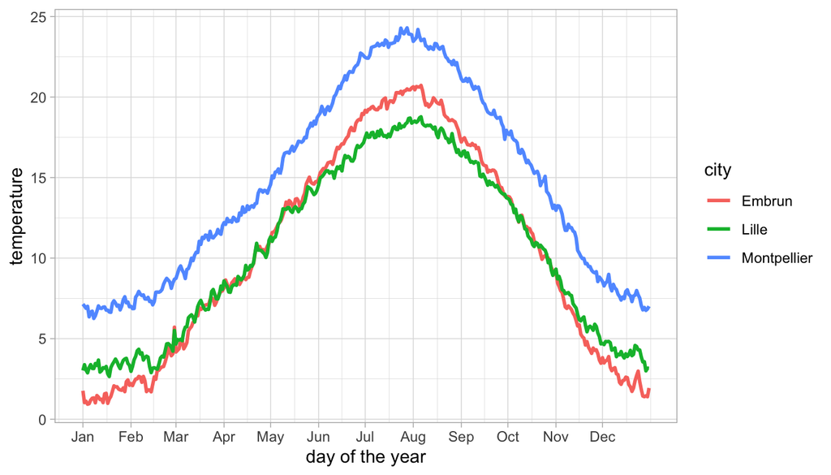

- `y` contient l’information sur la `temperature`.
- `color` contient l’information sur la `city`.

## Données climatiques - Graphique

Il faut choisir comment coder chaque information.

```
##            city day_of_year month temperature
## 1        Embrun           1     1    1.765714
## 367       Lille           1     1    3.024286
## 368       Lille           2     1    3.382857
## 733 Montpellier           1     1    7.147143
## 734 Montpellier           2     1    7.024286
```

“aestetics” possibles:

- Abscisses `x`
- Ordonnées `y`
- Couleurs `color`

\(~\)

- `day_of_year`
- `city`
- `temperature`

## Données climatiques - Graphique

Il faut choisir comment coder chaque information.

```
##            city day_of_year month temperature
## 1        Embrun           1     1    1.765714
## 367       Lille           1     1    3.024286
## 368       Lille           2     1    3.382857
## 733 Montpellier           1     1    7.147143
## 734 Montpellier           2     1    7.024286
```

```r
ggplot(temps_average) +
  aes(x = day_of_year, y = city, color = temperature) +
  geom_point(size = 5) +
  scale_x_continuous(name = "day of the year",
                     breaks = month_days_cum[-13] + 1,
                     labels = month_names) +
  scale_color_viridis_c(option = "B", begin = 0.15,
                        end = 0.98,name = "temperature") +
  theme_light()
```

## Données climatiques - color

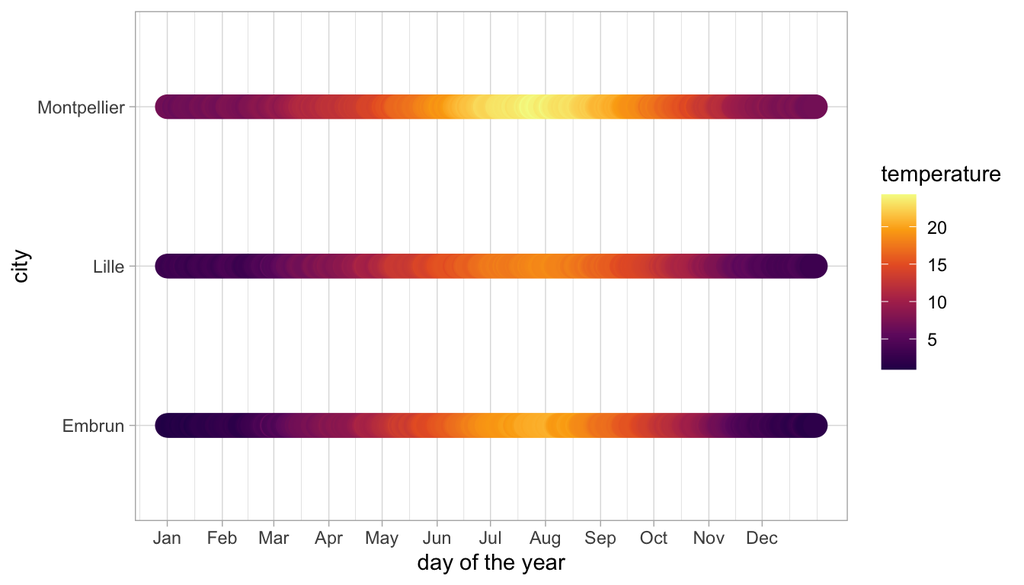

- `y` contient l’information sur la `city`.
- `color` contient l’information sur la `temperature`.

## Aesthetiques communes

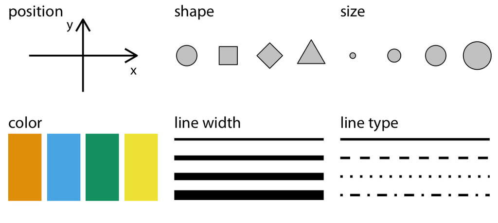

Figure tirée de [Claus O. Wilke. *Fundamentals of Data Visualization.* O’Reilly, 2019.](https://clauswilke.com/dataviz)

## Références

- *Fundamentals of Data Visualization*:  
  [Chapter 2: Visualizing data](https://clauswilke.com/dataviz/aesthetic-mapping.html)
- *Data Visualization—A Practical Introduction*:  
  [Chapter 3: Make a plot](https://socviz.co/makeplot.html#makeplot)
- [**ggplot2** reference documentation](https://ggplot2.tidyverse.org/reference/index.html)
- [**ggplot2** book](https://ggplot2-book.org/)
- [**ggplot2** cheatsheet](https://github.com/rstudio/cheatsheets/raw/master/data-visualization-2.1.pdf)